# XAI3

Samuel Marzano,Sergei Mintianskii and Rustam Suleimanov

# Intoduction

This analysis explores the interpretability of Random Forest models using Partial Dependence Plots (PDPs). This approach allows us to visualize the marginal influence of individual or combined variables on the predictions of complex models, without the need to inspect their internal structure.

Two case studies are addressed. The first focuses on a bike rental dataset, where we analyze how weather conditions and the passage of time affect rental demand. The second case examines house price prediction in the Seattle area, evaluating the influence of structural features such as the number of bedrooms, bathrooms, and living area. In both scenarios, Random Forest models are trained on relevant subsets of the data, and one-dimensional and two dimensional PDPs are generated to provide deeper insight into nonlinear relationships and variable interactions.

# One dimensional Partial Dependence Plot

To analyze the influence of key variables on the predicted bike rentals (cnt), we trained a Random Forest model using the features temp, hum, windspeed, and instant (which represents the number of days since 2011). We then used Partial Dependence Plots (PDPs) to visualize the marginal effect of each feature on the model’s predictions.

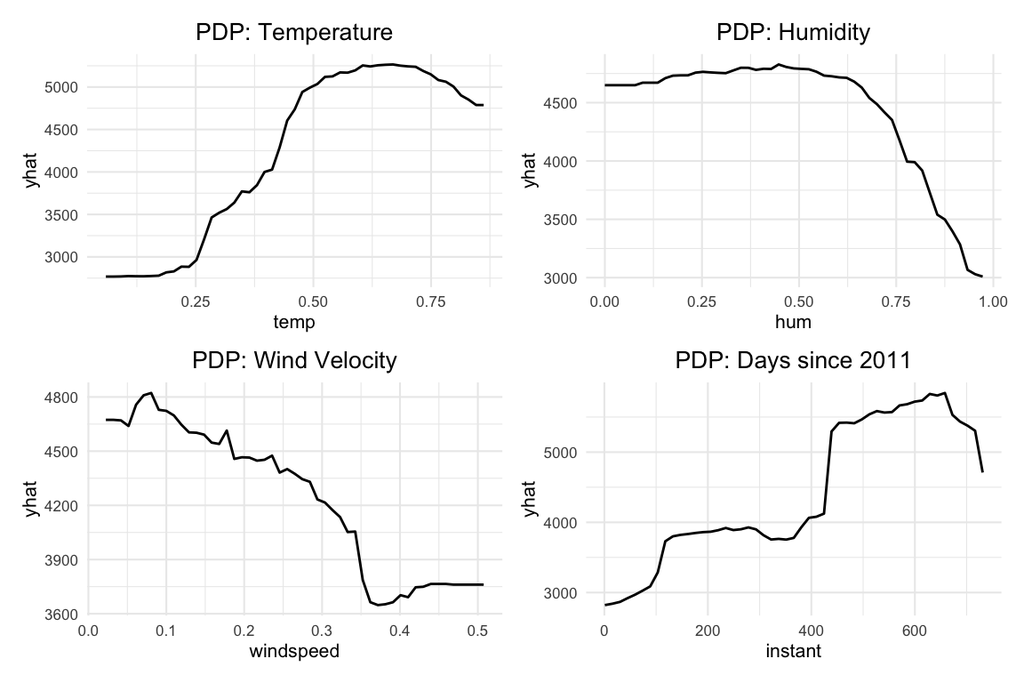

- **Temperature (`temp`)**  
  Temperature shows a strong positive influence on bike rentals up to a normalized value of approximately 0.7. As temperature rises, the number of predicted rentals increases significantly, peaking near that value. Beyond this point, the effect plateaus or slightly declines, suggesting that extreme heat may reduce bike usage.
- **Humidity (`hum`)**  
  Humidity has a negative impact on bike rentals. When humidity is low to moderate, predicted rentals are stable and relatively high. However, as humidity approaches 1.0, the predicted bike count drops sharply. This implies that people are less likely to rent bikes under very humid conditions.
- **Wind speed (`windspeed`)**  
  Wind speed also shows a decreasing relationship with bike usage. The PDP reveals that higher wind speeds slightly reduce the number of predicted rentals, although the effect is less dramatic compared to temperature or humidity.
- **Days since 2011 (`instant`)**  
  This variable captures a clear upward trend. The PDP shows that over time, the number of predicted rentals increased significantly, especially after day 400 (roughly March 2012). This reflects the growing popularity and adoption of the bike rental service over the two-year period.

To sumarise, the temperature and time progression are the strongest drivers of bike rental demand, while humidity and wind speed act as deterrents under unfavorable weather conditions. The PDPs provide a model-agnostic explanation of how each feature affects predictions, offering interpretability regardless of the internal structure of the Random Forest.

# 2. Bidimensional Partial Dependency Plot.

In this section, we examine the joint effect of temperature (`temp`) and humidity (`hum`) on the predicted number of bike rentals (`cnt`) using a 2D Partial Dependence Plot.

To avoid performance issues due to dataset size, we selected a random sample of 500 rows from the `day.csv` dataset. A new Random Forest model was trained using only `temp` and `hum` as predictors. We then computed the partial dependence surface using a grid of resolution 20, and visualized the predictions using `geom_tile()` with a continuous color scale (`viridis`).

The following heatmap shows the predicted bike count (represented by color intensity) for combinations of temperature (x-axis) and humidity (y-axis):

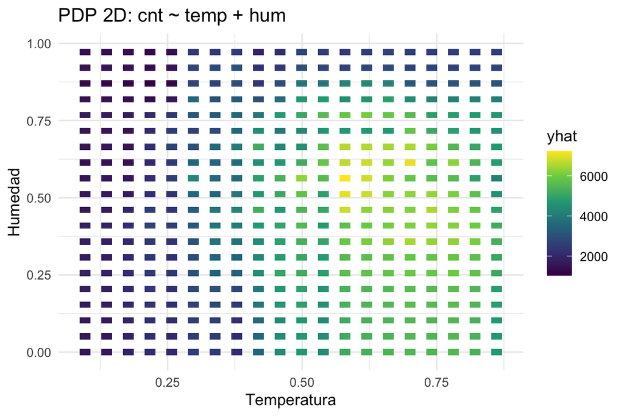

# 3. PDP to explain the price of a house.

To analyze how specific features influence house prices, we used the kc_house_data.csv dataset. Due to its large size, we extracted a random sample of 1,000 rows and trained a Random Forest model to predict price using the variables bedrooms, bathrooms, sqft_living, sqft_lot, floors, and yr_built. Then, we visualized the partial dependence of four key variables: bedrooms, bathrooms, sqft_living, and floors.

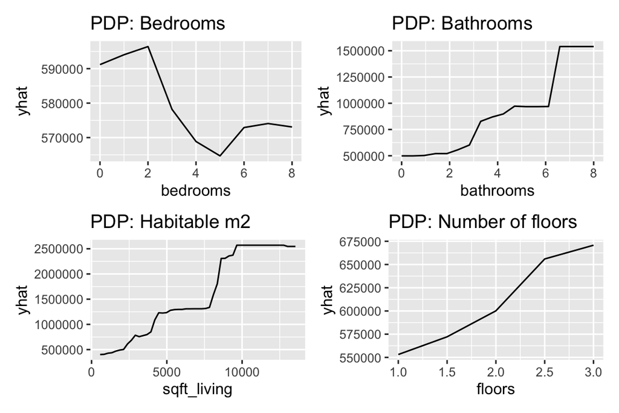

- **Bedrooms (`bedrooms`)**  
  The number of bedrooms shows a non-linear and weak influence on the predicted price. While prices increase slightly up to 2 bedrooms, the effect diminishes or even reverses for houses with 3 to 5 bedrooms. This could indicate that additional rooms do not always imply higher value, possibly due to lower-quality housing. Beyond 6 bedrooms, the price stabilizes.
- **Bathrooms (`bathrooms`)**  
  Bathrooms have a strong and clearly positive impact on price. From 3 bathrooms onward, the predicted price rises rapidly. A sharp increase is observed around 6–7 bathrooms, suggesting the presence of luxury homes in that range.
- **Living area (`sqft_living`)**  
  This variable exhibits the most pronounced effect. Predicted prices grow steadily with more square meters of habitable space, especially after 4,000 sqft. Larger houses correlate with significantly higher valuations, confirming the economic value of spacious interiors.
- **Floors (`floors`)**  
  The number of floors also shows a consistent upward trend. Houses with more floors (especially 3) are generally predicted to have higher prices. This may be due to architectural prestige, better views, or larger usable area.

# Conclusions

These results illustrate how PDPs can break down the contribution of each feature, making the model more interpretable and aiding informed decision-making in both urban planning and real estate contexts. This technique thus stands out as a practical explanatory tool for predictive models in applied data science.